# Bankruptcy Clustering

Zeedan Shaikh

2024-09-06

## Introduction

Clustering banks based on bankruptcy risk is a crucial analytical approach for understanding and managing financial stability within the banking sector. By grouping banks with similar risk profiles, stakeholders can better assess potential vulnerabilities, allocate resources efficiently, and implement targeted strategies. This method provides a structured way to address the complexities of financial risk and improve overall oversight and intervention efforts.

### motivation

- **Risk Assessment and Management:**
  - Identifies banks with similar bankruptcy risks for targeted risk management.
  - Facilitates the development of specific strategies for managing financial distress.
- **Resource Allocation:**
  - Enables efficient allocation of monitoring and support resources to high-risk banks.
  - Prioritizes intervention efforts based on cluster risk levels.
- **Regulatory Oversight:**
  - Helps regulators design tailored policies and regulations for different risk clusters.
  - Supports focused oversight and preventive measures.
- **Predictive Analysis:**
  - Enhances predictive models by analyzing groups of banks with comparable financial profiles.
  - Improves the forecasting of potential financial crises and systemic risks.
- **Strategic Planning:**
  - Assists banks in understanding their position relative to peers within the same risk cluster.
  - Aids in formulating strategies for risk reduction and financial stability.
- **Investment Decisions:**
  - Guides investors in evaluating the risk profiles of banks and making informed investment choices.
  - Highlights potential investment risks and opportunities based on cluster analysis.
- **Crisis Management:**
  - Improves crisis preparedness by identifying high-risk clusters requiring immediate attention.
  - Supports the development of tailored contingency plans for different risk levels.
- **Performance Benchmarking:**
  - Facilitates comparison and benchmarking of banks within similar risk clusters.
  - Helps assess performance metrics and identify best practices among peers.
- **Data-Driven Insights:**
  - Provides a structured approach to analyzing bankruptcy risks, leading to more informed decision-making.
  - Enhances understanding of systemic vulnerabilities and strengths.
- **Enhanced Communication:**
  - Clarifies risk discussions between banks, regulators, and stakeholders through a structured framework.
  - Improves transparency and rationale behind regulatory decisions and interventions.

### Objective

Here our objective is to cluster the data points.

## Methodology

### Data collection

The data is obtained from kaggle Dataset name : **Company Bankruptcy Prediction**

**Variable Details**

**Y** - Bankrupt?: Class label

**X1** - ROA(C) before interest and depreciation before interest: Return On Total Assets(C)

**X2** - ROA(A) before interest and % after tax: Return On Total Assets(A)

**X3** - ROA(B) before interest and depreciation after tax: Return On Total Assets(B)

**X4** - Operating Gross Margin: Gross Profit/Net Sales

**X5** - Realized Sales Gross Margin: Realized Gross Profit/Net Sales

**X6** - Operating Profit Rate: Operating Income/Net Sales

**X7** - Pre-tax net Interest Rate: Pre-Tax Income/Net Sales

**X8** - After-tax net Interest Rate: Net Income/Net Sales

**X9** - Non-industry income and expenditure/revenue: Net Non-operating Income Ratio

**X10** - Continuous interest rate (after tax): Net Income-Exclude Disposal Gain or Loss/Net Sales

**X11** - Operating Expense Rate: Operating Expenses/Net Sales

**X12** - Research and development expense rate: (Research and Development Expenses)/Net Sales

**X13** - Cash flow rate: Cash Flow from Operating/Current Liabilities

**X14** - Interest-bearing debt interest rate: Interest-bearing Debt/Equity

**X15** - Tax rate (A): Effective Tax Rate

**X16** - Net Value Per Share (B): Book Value Per Share(B)

**X17** - Net Value Per Share (A): Book Value Per Share(A)

**X18** - Net Value Per Share (C): Book Value Per Share(C)

**X19** - Persistent EPS in the Last Four Seasons: EPS-Net Income

**X20** - Cash Flow Per Share

**X21** - Revenue Per Share (Yuan ¥): Sales Per Share

**X22** - Operating Profit Per Share (Yuan ¥): Operating Income Per Share

**X23** - Per Share Net profit before tax (Yuan ¥): Pretax Income Per Share

**X24** - Realized Sales Gross Profit Growth Rate

**X25** - Operating Profit Growth Rate: Operating Income Growth

**X26** - After-tax Net Profit Growth Rate: Net Income Growth

**X27** - Regular Net Profit Growth Rate: Continuing Operating Income after Tax Growth

**X28** - Continuous Net Profit Growth Rate: Net Income-Excluding Disposal Gain or Loss Growth

**X29** - Total Asset Growth Rate: Total Asset Growth

**X30** - Net Value Growth Rate: Total Equity Growth

**X31** - Total Asset Return Growth Rate Ratio: Return on Total Asset Growth

**X32** - Cash Reinvestment %: Cash Reinvestment Ratio

**X33** - Current Ratio

**X34** - Quick Ratio: Acid Test

**X35** - Interest Expense Ratio: Interest Expenses/Total Revenue

**X36** - Total debt/Total net worth: Total Liability/Equity Ratio

**X37** - Debt ratio %: Liability/Total Assets

**X38** - Net worth/Assets: Equity/Total Assets

**X39** - Long-term fund suitability ratio (A): (Long-term Liability+Equity)/Fixed Assets

**X40** - Borrowing dependency: Cost of Interest-bearing Debt

**X41** - Contingent liabilities/Net worth: Contingent Liability/Equity

**X42** - Operating profit/Paid-in capital: Operating Income/Capital

**X43** - Net profit before tax/Paid-in capital: Pretax Income/Capital

**X44** - Inventory and accounts receivable/Net value: (Inventory+Accounts Receivables)/Equity

**X45** - Total Asset Turnover

**X46** - Accounts Receivable Turnover

**X47** - Average Collection Days: Days Receivable Outstanding

**X48** - Inventory Turnover Rate (times)

**X49** - Fixed Assets Turnover Frequency

**X50** - Net Worth Turnover Rate (times): Equity Turnover

**X51** - Revenue per person: Sales Per Employee

**X52** - Operating profit per person: Operation Income Per Employee

**X53** - Allocation rate per person: Fixed Assets Per Employee

**X54** - Working Capital to Total Assets

**X55** - Quick Assets/Total Assets

**X56** - Current Assets/Total Assets

**X57** - Cash/Total Assets

**X58** - Quick Assets/Current Liability

**X59** - Cash/Current Liability

**X60** - Current Liability to Assets

**X61** - Operating Funds to Liability

**X62** - Inventory/Working Capital

**X63** - Inventory/Current Liability

**X64** - Current Liabilities/Liability

**X65** - Working Capital/Equity

**X66** - Current Liabilities/Equity

**X67** - Long-term Liability to Current Assets

**X68** - Retained Earnings to Total Assets

**X69** - Total income/Total expense

**X70** - Total expense/Assets

**X71** - Current Asset Turnover Rate: Current Assets to Sales

**X72** - Quick Asset Turnover Rate: Quick Assets to Sales

**X73** - Working capitcal Turnover Rate: Working Capital to Sales

**X74** - Cash Turnover Rate: Cash to Sales

**X75** - Cash Flow to Sales

**X76** - Fixed Assets to Assets

**X77** - Current Liability to Liability

**X78** - Current Liability to Equity

**X79** - Equity to Long-term Liability

**X80** - Cash Flow to Total Assets

**X81** - Cash Flow to Liability

**X82** - CFO to Assets

**X83** - Cash Flow to Equity

**X84** - Current Liability to Current Assets

**X85** - Liability-Assets Flag: 1 if Total Liability exceeds Total Assets, 0 otherwise

**X86** - Net Income to Total Assets

**X87** - Total assets to GNP price

**X88** - No-credit Interval

**X89** - Gross Profit to Sales

**X90** - Net Income to Stockholder’s Equity

**X91** - Liability to Equity

**X92** - Degree of Financial Leverage (DFL)

**X93** - Interest Coverage Ratio (Interest expense to EBIT)

**X94** - Net Income Flag: 1 if Net Income is Negative for the last two years, 0 otherwise

**X95** - Equity to Liability

### Data preparation

Getting the required packages:

```r
pacman::p_load(MASS,clValid,cluster,dbscan,ggplot2)
```

Importing and cleaning the dataset:

```r
mydata=read.csv("C:\\Users\\zeeda\\Downloads\\archive (3)\\data.csv")
```

- First check if the data is balanced or not i.e. whether the no of bankrupt and non-bankrupt banks are equal.

```r
table(mydata$Bankrupt.)
```

```
   0    1
6599  220
```

Clearly the data is highly unbalanced as we have a lot of observation on banks that are not bankrupt and less on bankrupt. So we will use undersampling technique and reduce the cardinality of majority class ( non-bankrupt class)

```r
no_bankrupt=subset(mydata,mydata$Bankrupt.==0)
mydata_index=sample(1:nrow(no_bankrupt),201,F)
no_bankrupt_data=no_bankrupt[mydata_index,]
bankrupt_data=subset(mydata,mydata$Bankrupt.==1)
mydata=rbind(no_bankrupt_data,bankrupt_data)
table(mydata$Bankrupt.)
```

```
  0   1
201 220
```

- Now we have a balanced data.

**Summary of the data**

```r
summary(mydata)
```

```
   Bankrupt.      ROA.C..before.interest.and.depreciation.before.interest
 Min.   :0.0000   Min.   :0.02428
 1st Qu.:0.0000   1st Qu.:0.43100
 Median :1.0000   Median :0.46999
 Mean   :0.5226   Mean   :0.45699
 3rd Qu.:1.0000   3rd Qu.:0.50095
 Max.   :1.0000   Max.   :0.66187
 ROA.A..before.interest.and...after.tax
 Min.   :0.0000
 1st Qu.:0.4715
 Median :0.5300
 Mean   :0.5031
 3rd Qu.:0.5624
 Max.   :0.7135
 ROA.B..before.interest.and.depreciation.after.tax Operating.Gross.Margin
 Min.   :0.03351                                   Min.   :0.5026
 1st Qu.:0.47240                                   1st Qu.:0.5968
 Median :0.52203                                   Median :0.6015
 Mean   :0.50242                                   Mean   :0.6026
 3rd Qu.:0.55164                                   3rd Qu.:0.6094
 Max.   :0.71005                                   Max.   :0.6652
 Realized.Sales.Gross.Margin Operating.Profit.Rate Pre.tax.net.Interest.Rate
 Min.   :0.5026              Min.   :0.9919        Min.   :0.7572
 1st Qu.:0.5970              1st Qu.:0.9989        1st Qu.:0.7971
 Median :0.6015              Median :0.9990        Median :0.7974
 Mean   :0.6026              Mean   :0.9989        Mean   :0.7970
 3rd Qu.:0.6095              3rd Qu.:0.9990        3rd Qu.:0.7975
 Max.   :0.6652              Max.   :0.9994        Max.   :0.7986
 After.tax.net.Interest.Rate Non.industry.income.and.expenditure.revenue
 Min.   :0.7616              Min.   :0.2351
 1st Qu.:0.8090              1st Qu.:0.3032
 Median :0.8093              Median :0.3034
 Mean   :0.8089              Mean   :0.3030
 3rd Qu.:0.8094              3rd Qu.:0.3035
 Max.   :0.8103              Max.   :0.3058
 Continuous.interest.rate..after.tax. Operating.Expense.Rate
 Min.   :0.7427                       Min.   :0.000e+00
 1st Qu.:0.7813                       1st Qu.:0.000e+00
 Median :0.7815                       Median :0.000e+00
 Mean   :0.7812                       Mean   :1.938e+09
```

[output cut: 253 more lines]

```
 Max.   :0.26458
 Interest.Coverage.Ratio..Interest.expense.to.EBIT. Net.Income.Flag
 Min.   :0.5396                                     Min.   :1
 1st Qu.:0.5645                                     1st Qu.:1
 Median :0.5652                                     Median :1
 Mean   :0.5652                                     Mean   :1
 3rd Qu.:0.5657                                     3rd Qu.:1
 Max.   :0.6241                                     Max.   :1
 Equity.to.Liability
 Min.   :0.003946
 1st Qu.:0.017881
 Median :0.022922
 Mean   :0.032996
 3rd Qu.:0.035854
 Max.   :0.798122
```

```r
dim(mydata)
```

```
[1] 421  96
```

- Clearly we have a really high number of predictor variable so we need to use derived inputs techniques (ex. Principle Component Analysis)

### Data Reduction

#### Principle Component Analysis

```r
data=mydata[,-1]
pca_model=prcomp(data,center = TRUE)
```

**Summary PCA model**

```r
summary(pca_model)
```

```
Importance of components:
                             PC1       PC2       PC3       PC4       PC5
Standard deviation     3.935e+09 3.396e+09 3.114e+09 2.829e+09 2.692e+09
Proportion of Variance 2.120e-01 1.579e-01 1.328e-01 1.096e-01 9.922e-02
Cumulative Proportion  2.120e-01 3.699e-01 5.027e-01 6.123e-01 7.115e-01
                             PC6       PC7       PC8       PC9      PC10
Standard deviation     2.577e+09 2.391e+09 2.338e+09 9.801e+08 7.080e+08
Proportion of Variance 9.090e-02 7.828e-02 7.482e-02 1.315e-02 6.860e-03
Cumulative Proportion  8.024e-01 8.807e-01 9.555e-01 9.687e-01 9.755e-01
                            PC11      PC12      PC13      PC14      PC15
Standard deviation     6.894e+08 5.242e+08 4.846e+08 4.499e+08 4.464e+08
Proportion of Variance 6.510e-03 3.760e-03 3.220e-03 2.770e-03 2.730e-03
Cumulative Proportion  9.820e-01 9.858e-01 9.890e-01 9.918e-01 9.945e-01
                            PC16      PC17      PC18      PC19      PC20   PC21
Standard deviation     3.852e+08 3.473e+08 3.175e+08 1.672e+08 6.381e+07 0.3341
Proportion of Variance 2.030e-03 1.650e-03 1.380e-03 3.800e-04 6.000e-05 0.0000
Cumulative Proportion  9.965e-01 9.982e-01 9.996e-01 9.999e-01 1.000e+00 1.0000
                        PC22   PC23   PC24   PC25   PC26   PC27    PC28    PC29
Standard deviation     0.204 0.1803 0.1364 0.1292 0.1214 0.1073 0.08982 0.07185
Proportion of Variance 0.000 0.0000 0.0000 0.0000 0.0000 0.0000 0.00000 0.00000
Cumulative Proportion  1.000 1.0000 1.0000 1.0000 1.0000 1.0000 1.00000 1.00000
                          PC30    PC31    PC32    PC33    PC34    PC35    PC36
Standard deviation     0.06757 0.06359 0.04768 0.04312 0.04012 0.03486 0.03439
Proportion of Variance 0.00000 0.00000 0.00000 0.00000 0.00000 0.00000 0.00000
Cumulative Proportion  1.00000 1.00000 1.00000 1.00000 1.00000 1.00000 1.00000
                          PC37    PC38    PC39   PC40    PC41    PC42    PC43
Standard deviation     0.03116 0.02865 0.02415 0.0232 0.01944 0.01828 0.01759
Proportion of Variance 0.00000 0.00000 0.00000 0.0000 0.00000 0.00000 0.00000
Cumulative Proportion  1.00000 1.00000 1.00000 1.0000 1.00000 1.00000 1.00000
                          PC44    PC45   PC46   PC47    PC48    PC49    PC50
Standard deviation     0.01592 0.01541 0.0144 0.0129 0.01245 0.01194 0.01156
Proportion of Variance 0.00000 0.00000 0.0000 0.0000 0.00000 0.00000 0.00000
Cumulative Proportion  1.00000 1.00000 1.0000 1.0000 1.00000 1.00000 1.00000
                          PC51    PC52     PC53     PC54     PC55     PC56
Standard deviation     0.01122 0.01051 0.009228 0.009004 0.008532 0.007524
Proportion of Variance 0.00000 0.00000 0.000000 0.000000 0.000000 0.000000
Cumulative Proportion  1.00000 1.00000 1.000000 1.000000 1.000000 1.000000
                           PC57     PC58     PC59     PC60     PC61     PC62
Standard deviation     0.007008 0.006925 0.005751 0.005057 0.004643 0.004302
Proportion of Variance 0.000000 0.000000 0.000000 0.000000 0.000000 0.000000
```

[output cut: 14 more lines]

```
Standard deviation     0.0004639 0.0004055 0.0003805 0.0003421 0.0001499
Proportion of Variance 0.0000000 0.0000000 0.0000000 0.0000000 0.0000000
Cumulative Proportion  1.0000000 1.0000000 1.0000000 1.0000000 1.0000000
                            PC85      PC86      PC87      PC88      PC89
Standard deviation     9.517e-05 7.399e-05 2.648e-05 2.245e-05 1.312e-06
Proportion of Variance 0.000e+00 0.000e+00 0.000e+00 0.000e+00 0.000e+00
Cumulative Proportion  1.000e+00 1.000e+00 1.000e+00 1.000e+00 1.000e+00
                            PC90      PC91      PC92      PC93      PC94
Standard deviation     3.157e-07 3.157e-07 3.157e-07 3.157e-07 3.157e-07
Proportion of Variance 0.000e+00 0.000e+00 0.000e+00 0.000e+00 0.000e+00
Cumulative Proportion  1.000e+00 1.000e+00 1.000e+00 1.000e+00 1.000e+00
                            PC95
Standard deviation     2.843e-07
Proportion of Variance 0.000e+00
Cumulative Proportion  1.000e+00
```

We will obtain Screeplot and Cumulative variance plot

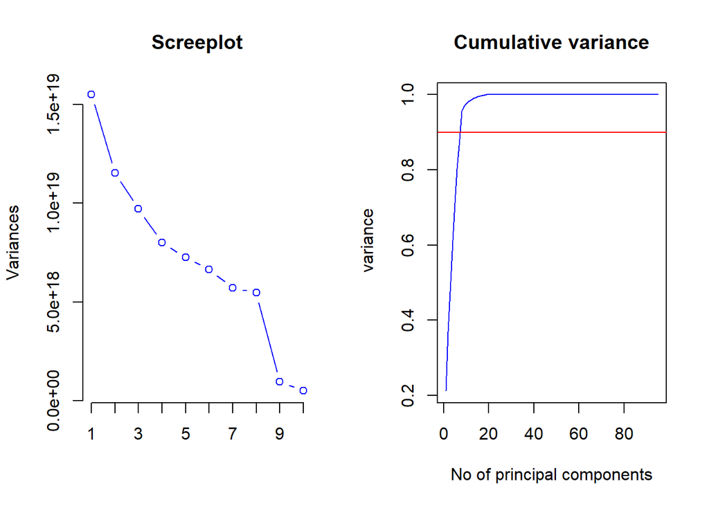

```r
par(mfrow=c(1,2))
plot(pca_model,typ="l",main= "Screeplot",col="blue")
variance_plot=cumsum((pca_model$sdev^2)/sum(pca_model$sdev^2))
plot(variance_plot,type="l",main="Cumulative variance",xlab="No of principal components",ylab=" variance",col="blue")
abline(h=0.9,col="red")
```

```r
rotation_matrix=pca_model$rotation
reduced_rotation_matrix=rotation_matrix[,-c(8:95)]
final_data=as.matrix(data)%*%reduced_rotation_matrix
dim(final_data)
```

```
[1] 421   7
```

**Now we will apply different Clustering Techniques**

### Clustering

#### K-means

- We will use kmeans to obtain different no of clusters.
- compute **Dunn Index** for each of the model and plot it.
- Choose the model with largest Dunn Index value and select the corresponding no of cluster.

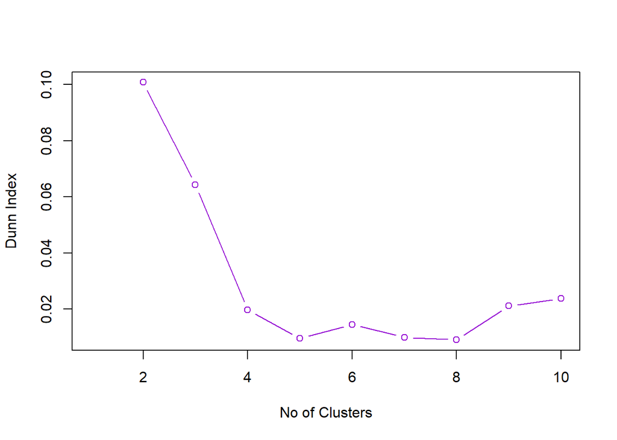

```r
set.seed(12)
dun_index=c()
for(i in 2:10){
  obj=kmeans(x=final_data,i)
  dun_index[i]=dunn(dist(final_data),as.vector(obj$cluster))
}
plot(dun_index,typ="b",xlab="No of Clusters",ylab="Dunn Index",col="darkviolet")
```

- *The Dunn Index is max when the cluster number is*

```r
which.max(dun_index)
```

```
[1] 2
```

- Now we will check the accuracy how well the method is been able to classify the two data

```r
#--optimal clustering
set.seed(12)
obj=kmeans(final_data,2)
cluster_vector=obj$cluster
#--class labels
class_vector=mydata$Bankrupt.
```

```r
#--Accuracy
True_Positive=0
False_Negetive=0
True_Negetive=0
False_Positive=0
for(i in 1:nrow(final_data)){
  if(class_vector[i]==0){
    if(cluster_vector[i]==1)
      True_Positive=True_Positive+1
    else
      False_Negetive=False_Negetive+1
    }
  else{
    if(cluster_vector[i]==2)
      True_Negetive=True_Negetive+1
    else
      False_Positive=False_Positive+1
  }
}
Confusion_mat=matrix(c(True_Positive,False_Negetive,True_Negetive,False_Positive),nc=2)
Accuracy=(sum(diag(Confusion_mat))/sum(Confusion_mat))*100
Accuracy
```

```
[1] 47.981
```

- Which is Quiet less.

#### PAM (Partioning Around Medoids)

- We will use PAM to obtain different no of clusters.
- compute **Dunn Index** for each of the model and plot it.
- Choose the model with largest Dunn Index value and select the corresponding no of cluster.
- We will also use silhouette plot to judge the number of clusters.

[figure not shown]

```r
set.seed(12)
for(i in 2:8){
  obj2=pam(final_data,i)
  dun_index[i]=dunn(dist(final_data),obj2$clustering) }
obj2=pam(final_data,2)
plot(obj2,which=2,main="silhouette plot")
```

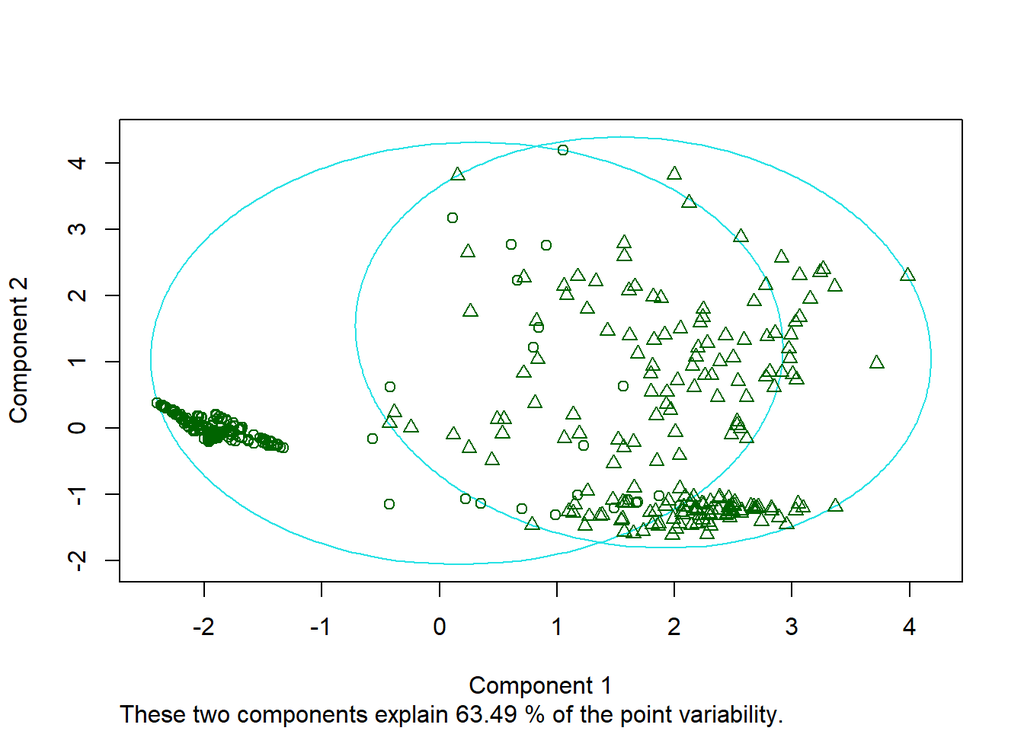

```r
plot(obj2,which=1,main="")
```

[figure not shown]

```r
obj2=pam(final_data,3)
plot(obj2,which=2,main="silhouette plot")
```

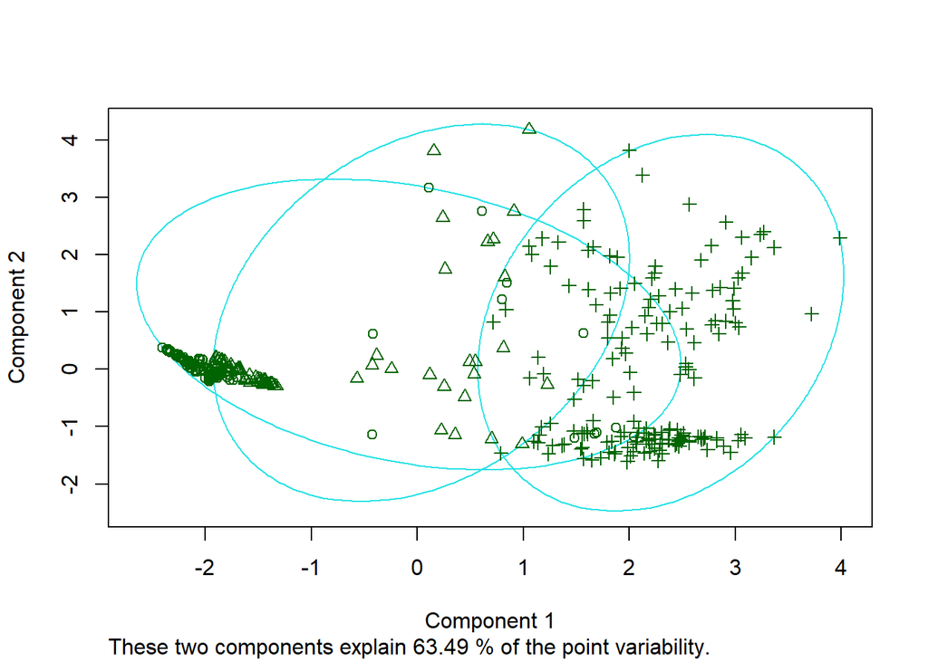

```r
plot(obj2,which=1,main="")
```

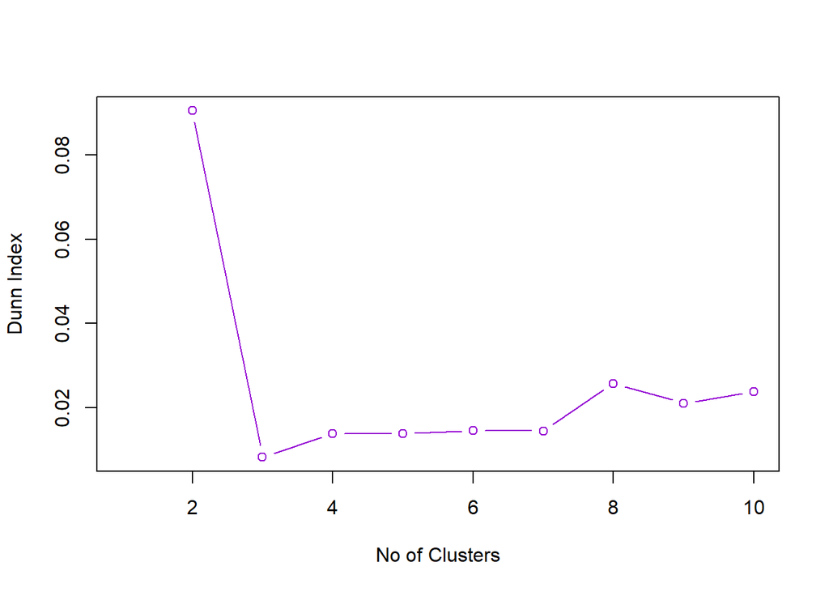

```r
plot(dun_index,typ="b",xlab="No of Clusters",ylab="Dunn Index",col="darkviolet")
```

- From the silhouette plot we get the maximum value of the silhouette coefficient 0.5 when the number of clusters is 2.
- 0.5 means the clusters are moderately well separated
- *The Dunn Index is max when the cluster number is*

```r
which.max(dun_index)
```

```
[1] 2
```

- Now we will check the accuracy how well the method is been able to classify the two data

```r
#--optimal clustering
set.seed(12)
obj2=pam(final_data,2)
cluster_vector=obj2$clustering
```

```r
#--Accuracy
True_Positive=0
False_Negetive=0
True_Negetive=0
False_Positive=0
for(i in 1:nrow(final_data)){
  if(class_vector[i]==0){
    if(cluster_vector[i]==1)
      True_Positive=True_Positive+1
    else
      False_Negetive=False_Negetive+1
    }
  else{
    if(cluster_vector[i]==2)
      True_Negetive=True_Negetive+1
    else
      False_Positive=False_Positive+1
  }
}
Confusion_mat=matrix(c(True_Positive,False_Negetive,True_Negetive,False_Positive),nc=2)
Accuracy=(sum(diag(Confusion_mat))/sum(Confusion_mat))*100
Accuracy
```

```
[1] 55.34442
```

- Which is still Quiet less.

#### AGNES (Single Linkage Algorithm)

- We will plot the dendogram using the above method.
- Cut the dendogram at different lengths to get different no of clusters.
- Then calculate Dunn Index based on it and get the optimal no of clusters.

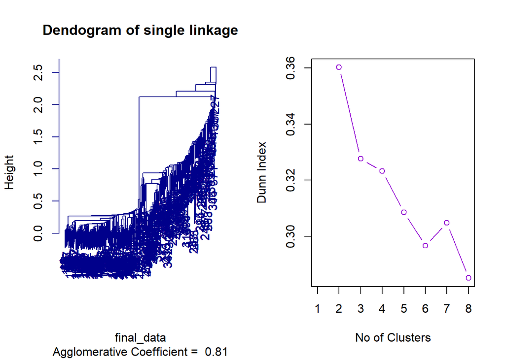

```r
par(mfrow=c(1,2))
obj3=agnes(final_data,method="single")
plot(obj3,which=2,main="Dendogram of single linkage",col="darkblue")
dun_index=c()
for(i in 2:8){
  clust=cutree(obj3,i)
  dun_index[i]=dunn(dist(final_data),clust) }
plot(dun_index,typ="b",xlab="No of Clusters",ylab="Dunn Index",col="darkviolet")
```

- The Agglomerative Coefficient 0.81 which means clusters are well formed.
- *The Dunn Index is max when the cluster number is*

```r
which.max(dun_index)
```

```
[1] 2
```

- Now we will check the accuracy how well the method is been able to classify the two data

```r
#--optimal clustering
obj3=agnes(final_data,method = "single")
clust=cutree(obj3,2)
cluster_vector=clust
```

```r
#--Accuracy
True_Positive=0
False_Negetive=0
True_Negetive=0
False_Positive=0
for(i in 1:nrow(final_data)){
  if(class_vector[i]==0){
    if(cluster_vector[i]==1)
      True_Positive=True_Positive+1
    else
      False_Negetive=False_Negetive+1
    }
  else{
    if(cluster_vector[i]==2)
      True_Negetive=True_Negetive+1
    else
      False_Positive=False_Positive+1
  }
}
Confusion_mat=matrix(c(True_Positive,False_Negetive,True_Negetive,False_Positive),nc=2)
Accuracy=(sum(diag(Confusion_mat))/sum(Confusion_mat))*100
Accuracy
```

[output not shown]

#### AGNES (complete Linkage Algorithm)

- We will plot the dendogram using the above method.
- Cut the dendogram at different lengths to get different no of clusters.
- Then calculate Dunn Index based on it and get the optimal no of clusters.

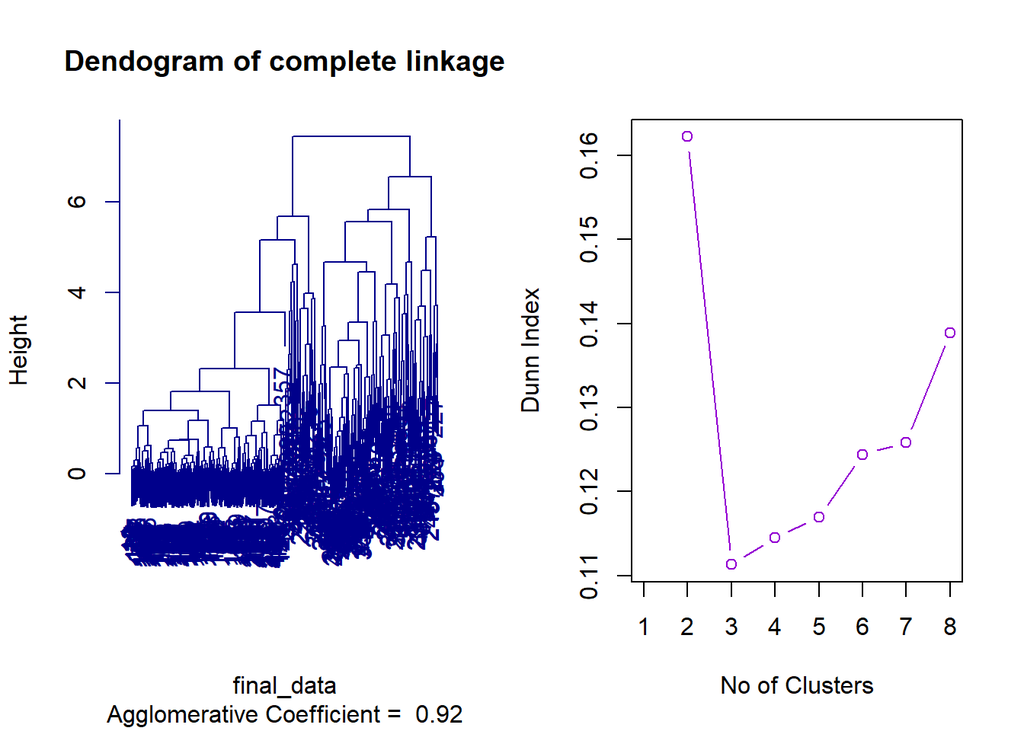

```r
par(mfrow=c(1,2))
obj3=agnes(final_data,method="complete")
plot(obj3,which=2,main="Dendogram of complete linkage",col="darkblue")
dun_index=c()
for(i in 2:8){
  clust=cutree(obj3,i)
  dun_index[i]=dunn(dist(final_data),clust) }
plot(dun_index,typ="b",xlab="No of Clusters",ylab="Dunn Index",col="darkviolet")
```

- The Agglomerative Coefficient 0.92 which means clusters are very well formed.
- *The Dunn Index is max when the cluster number is*

```r
which.max(dun_index)
```

```
[1] 2
```

- Now we will check the accuracy how well the method is been able to classify the two data

```r
#--optimal clustering
obj3=agnes(final_data,method = "complete")
clust=cutree(obj3,2)
cluster_vector=clust
```

```r
#--Accuracy
True_Positive=0
False_Negetive=0
True_Negetive=0
False_Positive=0
for(i in 1:nrow(final_data)){
  if(class_vector[i]==0){
    if(cluster_vector[i]==1)
      True_Positive=True_Positive+1
    else
      False_Negetive=False_Negetive+1
    }
  else{
    if(cluster_vector[i]==2)
      True_Negetive=True_Negetive+1
    else
      False_Positive=False_Positive+1
  }
}
Confusion_mat=matrix(c(True_Positive,False_Negetive,True_Negetive,False_Positive),nc=2)
Accuracy=(sum(diag(Confusion_mat))/sum(Confusion_mat))*100
Accuracy
```

```
[1] 60.09501
```

- Which is moderate.

#### DIANA (Divisive Analysis)

- We will plot the dendogram using the above method.
- Cut the dendogram at different lengths to get different no of clusters.
- Then calculate Dunn Index based on it and get the optimal no of clusters.

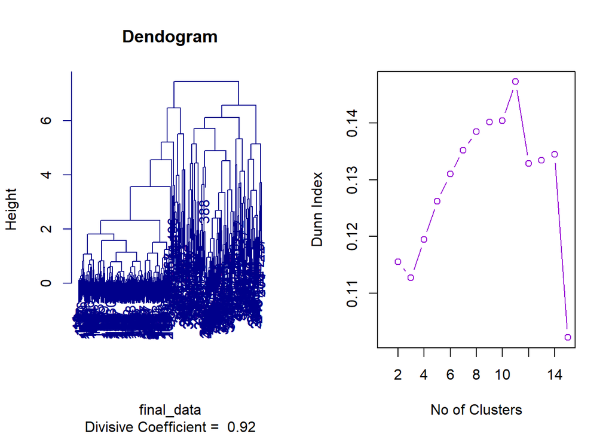

```r
par(mfrow=c(1,2))
obj5=diana(final_data)
plot(obj5,which=2,main="Dendogram",col="darkblue")
dun_index=c()
for(i in 2:15){
  clust=cutree(obj5,i)
  dun_index[i]=dunn(dist(final_data),clust) }
plot(dun_index,typ="b",xlab="No of Clusters",ylab="Dunn Index",col="darkviolet")
```

- The divisive Coefficient 0.92 which means clusters are very well formed.
- *The Dunn Index is max when the cluster number is*

```r
which.max(dun_index)
```

```
[1] 11
```

- Which is quiet different from the rest of the results obtained from different methods.
- Now we will check the accuracy how well the method is been able to classify the two data

```r
#--optimal clustering
obj5=diana(final_data)
clust=cutree(obj3,2)
cluster_vector=clust
```

```r
#--Accuracy
True_Positive=0
False_Negetive=0
True_Negetive=0
False_Positive=0
for(i in 1:nrow(final_data)){
  if(class_vector[i]==0){
    if(cluster_vector[i]==1)
      True_Positive=True_Positive+1
    else
      False_Negetive=False_Negetive+1
    }
  else{
    if(cluster_vector[i]==2)
      True_Negetive=True_Negetive+1
    else
      False_Positive=False_Positive+1
  }
}
Confusion_mat=matrix(c(True_Positive,False_Negetive,True_Negetive,False_Positive),nc=2)
Accuracy=(sum(diag(Confusion_mat))/sum(Confusion_mat))*100
Accuracy
```

```
[1] 60.09501
```

- Which is Very moderate.

#### DBSCAN (Density Based Spatial Clustering of Application with Noise)

- Here we will need initial value of two parameter *eps* and *minPts*
- Selecting *minPts* = (no of predictors in data +1)=8
- For *eps* we will obtain k-distance plot

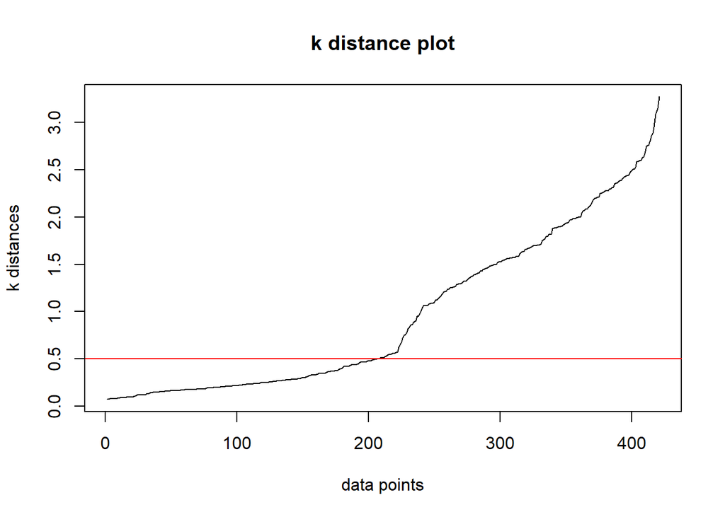

```r
mat=kNN(final_data, k = 8)
k_dist=sort(mat$dist[,8])
plot(k_dist,typ="l",xlab="data points",ylab="k distances",main="k distance plot")
abline(h=0.5,col="red")
```

- We will use a sequence of values around 0.5 .
- Create a Dunn Index plot and Choose the member of the sequence for which Dunn index will be maximum.

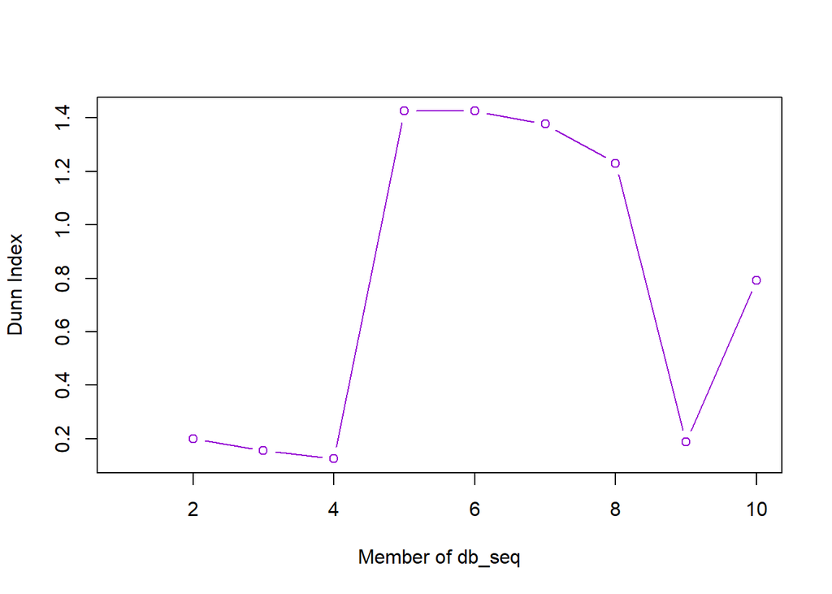

```r
db_seq=seq(0.1,2.0,0.1)
dun_index=c()
for(i in 2:10){
  obj6=dbscan(final_data,eps=db_seq[i],minPts=8)
  dun_index[i]=dunn(dist(final_data),obj6$cluster) }
plot(dun_index,typ="b",xlab="Member of db_seq",ylab="Dunn Index",col="darkviolet")
```

```r
which.max(dun_index)
```

```
[1] 5
```

The 5’th member is selected so we will choose **eps** =0.5

- Since we also have Noise points here we cannot directly calculate accuracy.
- We remove the noise points and calculate Accuracy with rest of the points.

```r
db=dbscan(final_data,eps=db_seq[5],minPts=8)
db
```

```
DBSCAN clustering for 421 objects.
Parameters: eps = 0.5, minPts = 8
Using euclidean distances and borderpoints = TRUE
The clustering contains 2 cluster(s) and 194 noise points.

  0   1   2
194 208  19

Available fields: cluster, eps, minPts, metric, borderPoints
```

```r
clus_vec=db$cluster
index_remove=which(clus_vec==0)
cluster_vector=clus_vec[-index_remove]
class_vector=mydata[-index_remove,]$Bankrupt.
```

```r
#--Accuracy
True_Positive=0
False_Negetive=0
True_Negetive=0
False_Positive=0
for(i in 1:nrow(final_data[-index_remove,])){
  if(class_vector[i]==0){
    if(cluster_vector[i]==1)
      True_Positive=True_Positive+1
    else
      False_Negetive=False_Negetive+1
    }
  else{
    if(cluster_vector[i]==2)
      True_Negetive=True_Negetive+1
    else
      False_Positive=False_Positive+1
  }
}
Confusion_mat=matrix(c(True_Positive,False_Negetive,True_Negetive,False_Positive),nc=2)
Accuracy=(sum(diag(Confusion_mat))/sum(Confusion_mat))*100
Accuracy
```

```
[1] 91.62996
```

- Which is Very Good.

#### OPTICS ( Ordering Points To Identify Clustering Structures)

- Here we used the value of **minPts** same as before.
- Select **eps** using the same analogy as before.
- We will use a sequence of values around 0.5 .
- Create a Dunn Index plot and Choose the member of the sequence for which Dunn index will be maximum.

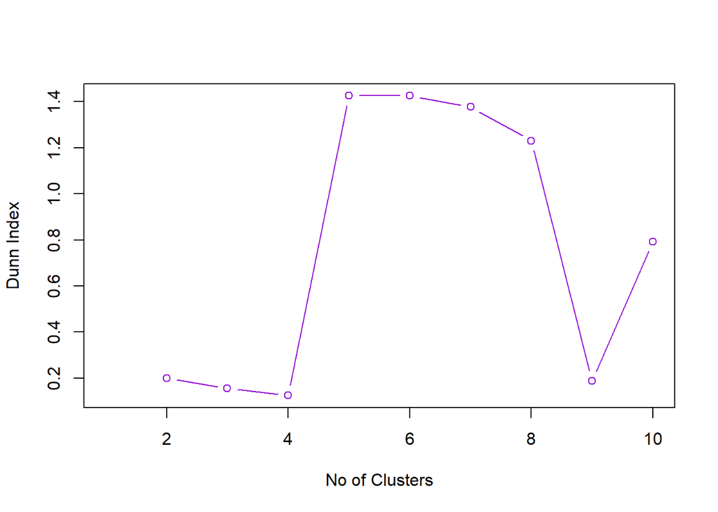

```r
dun_index=c()
for(i in 2:10){
  obj6=optics(final_data,eps=db_seq[i],minPts=8)
  dun_index[i]=dunn(dist(final_data),extractDBSCAN(obj6,db_seq[i])$cluster) }
plot(dun_index,typ="b",xlab="No of Clusters",ylab="Dunn Index",col="darkviolet")
```

```r
which.max(dun_index)
```

```
[1] 5
```

The 5’th member is selected so we will choose **eps** =0.5

- Since we also have Noise points here we cannot directly calculate accuracy.
- We remove the noise points and calculate Accuracy with rest of the points.
- We will visualize the the Reachability Plot

```r
op=optics(final_data,eps=db_seq[5],minPts=8)
table(extractDBSCAN(op,db_seq[5])$cluster)
```

```
  0   1   2
194 208  19
```

```r
clus_vec=extractDBSCAN(optics(final_data,eps=db_seq[5],minPts=8),db_seq[5])$cluster
index_remove=which(clus_vec==0)
cluster_vector=clus_vec[-index_remove]
```

```r
#--Accuracy
True_Positive=0
False_Negetive=0
True_Negetive=0
False_Positive=0
for(i in 1:nrow(final_data[-index_remove,])){
  if(class_vector[i]==0){
    if(cluster_vector[i]==1)
      True_Positive=True_Positive+1
    else
      False_Negetive=False_Negetive+1
    }
  else{
    if(cluster_vector[i]==2)
      True_Negetive=True_Negetive+1
    else
      False_Positive=False_Positive+1
  }
}
Confusion_mat=matrix(c(True_Positive,False_Negetive,True_Negetive,False_Positive),nc=2)
Accuracy=(sum(diag(Confusion_mat))/sum(Confusion_mat))*100
Accuracy
```

```
[1] 91.62996
```

- Which is Very Good.

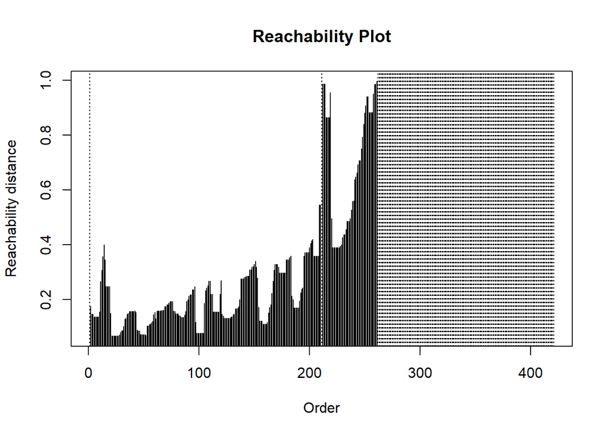

```r
plot(obj6,ylab="Reachability distance")
```

** Clearly We have 2 Clusters here with varying density.

## Project Report

### Summary findings

- The findings from different methods are summarized in the table below

### Conclusion

**In our analysis of bankruptcy data using clustering methods, we observed that several algorithms performed exceptionally well, achieving high classification accuracy. Specifically, the clustering methods produced two distinct clusters, which effectively separated the data into “bankrupt” and “non-bankrupt” categories.**

**The high accuracy achieved by 3 methods indicates that the clustering algorithms were successful in identifying and grouping data points according to their bankruptcy status. This suggests that the underlying structure of the data is well-represented by the two-cluster model, and that the chosen clustering techniques are well-suited for this classification task.**

**Overall, the results underscore the effectiveness of clustering as a tool for distinguishing between bankrupt and non-bankrupt entities, validating the robustness of the algorithms used. This not only demonstrates the algorithms’ capability in handling this specific classification problem but also highlights their potential for broader applications in similar data analysis scenarios.**